# Regression Analysis and Correlation

Der Versuch, Regressionsanalyse und Korrelation im Rahmen einer Unterrichtsstunde ab zu handeln, beziehungsweise dies in ein Kapitel zu stecken, ist recht ambitioniert. Zugegebener Weise. Dennoch wollen wir versuchen, in angemessener Kürze die wichtigsten Begriffe und Techniken zur Analyse des Zusammenhanges zwischen zwei Variablen darzustellen. Vieles muss dabei sicher oberflächlich bleiben, aber ich denke, es ist trotzdem sehr hilfreich, einen ersten Einblick in dieses Feld der Untersuchungen zu wagen. Ist es doch so, dass viele Techniken und Ideen, die im Rahmen einer einfachen Regressionsanalyse zum tragen kommen, in Weiterführenden statistischen Verfahren, besonders im Bereich der Modellierung, eine wichtige Rolle spielen. Hier können wir sie nun in überschaubarem und sicheren Rahmen ausprobieren. Sollten Sie nach dieser Veranstaltung Lust gewonnen haben, sich tiefergehend mit der Thematik der statistischen Analyse zu beschäftigen, haben Sie damit schon mal ein paar Grundlagen, auf denen sie aufbauen können.

## What is a regression? Some Terms and Definitions

### Regression

Regression beziehungsweise Regressionsanalyse ist ein Werkzeugkasten, der verschiedene statistische Verfahren und Methoden enthält, mit denen die Beziehungen zweier oder mehr Variablen untersucht werden können. Die Grundform stellt dabei die Frage dar, welchen Einfluss eine der beiden variablen, die auch als unabhängige oder erklärende variable benannt wird, auf eine zweite variable hat, die Abhängige die abhängige oder erklärte variable genannt wird. Versuchen wir uns das doch einmal mit einer Diagramm zu verdeutlichen:

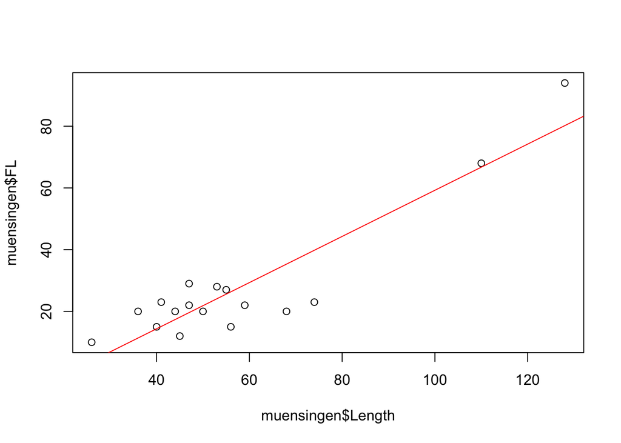

Ich habe bewusst bei diesem Diagramm auf Verschönerung in der Achsen verzichtet, damit wir die variablen direkt sehen. Was hier dargestellt ist, sind zwei Messwerte von latenezeitlichen Fibeln, die auf dem Gräberfeld Münsingen Rain, nicht weit entfernt von Bern, gefunden worden sind. Um genauer zu sein, sehen wir hier auf der X-Achse die Gesamtlänge der Fibeln aufgetragen, während wir auf der Y Achse die Länge des Fusses der einzelnen Fibeln wiedergegeben finden. Die einzelnen Punktestellen jeweils die einzelnen Fibeln in Bezug auf ihre Gesamtlänge und ihre Fusslänge da. Wir kennen diese Darstellungsform ja seit einigen Kapiteln als Streudiagramm. Keine Überraschung also bis hierher.

Was genau sehen wir hier: zum einen sehen wir zwei Ausreisser. Das sind die beiden Punkte recht weit rechts oben im Diagramm. Im linken unteren Quadranten finden sich die meisten anderen Datenpunkte. Frei hingegen sind der obere linke Quadrant, wie auch der untere rechte. Mit sehr viel guten willen kann man sagen, dass die Datenpunkte Sich mehr oder weniger um eine Linie kopieren, die von links unten nach rechts oben verläuft. Um unsere Fantasie auf die Sprünge zu helfen, habe ich gleich mal eine entsprechende Linie eingezeichnet. Sehr suggestiv schaut sie aus.

Dass die Datenpunkte umso höher liegen, hier weiter nach rechts wir uns in Diagramm bewegen, ist sicher auch von Ihnen leicht zu interpretieren: je grösser die Länge der Fibeln wird, umso grösser wird auch die Länge der Fibelfüsse. Rein aus archäologischen wissen können wir hier leicht einen Zusammenhang ableiten: Fibeln Folgen einer gewissen, vorgegebenen Formgebung. Wenn die Fibeln grösser werden, müssen auch ihre Füsse grösser werden. Und dies können wir anhand dieses Diagrammes beobachten.

Wir sehen also im Diagramm einen Zusammenhang zwischen zwei variablen wiedergegeben: Die Länge der Füsse der Fibeln in Bezug auf die Gesamtlänge. In unserer Darstellung ist die Gesamtlänge die variable, die wahrscheinlich die Ursache für die Veränderung der Fusslänge darstellt. Zumindest habe ich dies im Absatz darüber gerade zum Ausdruck gebracht. Diese variable würde man als unabhängige variable bezeichnen, gegebenenfalls auch als erklärende variable. Was erklärt jetzt diese variable? Nun, sie erklärt die Entwicklung Der Fusslänge, also unserer zweiten variable. In unserer Interpretation ist diese zweite variable bzw. deren Werte abhängig von der Entwicklung der ersten variable. Mit der Veränderung ersten variable können wir die Veränderung der zweiten variable erklären, sie ist also die erklärte variable.

Neben der einfachen Tatsache, dass es hier anscheinend einen Zusammenhang zwischen den beiden variablen gibt, sehen wir noch mehr: zum einen, und das haben wir bereits angesprochen, können wir die Richtung des Zusammenhanges erkennen. Wenn die Länge grösser wird, wird auch die Fusslänge grösser. Die variable länger hat also einen positiven Einfluss auf die variable Fusslänge. In diesem Zusammenhang spricht man auch von einer positiven Regression. Wir werden gleich noch andere Beispiele sehen. Zudem können wir erkennen, dass eine Linie ganz gut das Verhältnis bei der variablen beschreibt. Ausserdem ist im Grossen und Ganzen ein gleichmässiger Zusammenhang festzustellen. Es gibt keinen Bereich, in dem sich der Zusammenhang umgekehrt. Was wir auch sehen können, ist, dass die Punkte relativ dicht an der Linie liegen. Wissen wir die Gesamtlänge, so können wir mit einiger Sicherheit den Bereich bestimmen, in dem sich die Fusslänge bewegen wird.

Im Grunde genommen haben wir mit der Betrachtung dieses Diagramm es bereits eine Regressionsanalyse durchgeführt. Im folgenden werden wir Werkzeuge kennen lernen, mit deren Hilfe wir dies noch genauer, und vor allen Dingen quantitativer durchführen können.

Im folgenden sollen einige Variationen von Regression, also möglichen Zusammenhängen zwischen zwei variablen, dargestellt werden. Ich werde auf die einzelnen Abbildungen im folgenden kurz eingehen.

[figure not shown]

Die häufigste Form ist die so genannte lineare Regression. Diese liegt vor, wenn sich die Daten am besten mit einer Linie beschreiben lassen. Die oberen beiden Diagramme Stellen jeweils lineare Regression da. Die Linien gehen aber in unterschiedliche Richtungen: in der Abbildung links oben sehen wir eine positive Regression, wie wir sie auch Am Beispiel der Fibeln vorliegen haben. Hier dargestellt ist der Zusammenhang zwischen der Höhe von Gefässen und ihrem Randdurchmesser. Die Grösse ein Gefäss ist, umso grösser ist auch der Durchmesser des Randes. Die Abbildung rechts oben stellt eine negative Regression da. Hier sehen wir Häufigkeit eines bestimmten Keramik Typs in Abhängigkeit von der Entfernung von dem Produktions Ort dieser Ware. Je weiter wir uns von Produktions Ort entfernen, umso geringer wird die Häufigkeit dieses keramiktypes An Fundmaterial in Ausgrabungen in der Umgebung. Allgemein gesagt, wird die eine variable kleiner, wenn die andere grösser wird. Dennoch lässt sich auch hier eine Linie finden, die den Zusammenhang zwischen den variablen gut beschreibt.

Anders sieht es in den beiden Beispielen darunter aus. Das linke Beispiel zeigt eine deutliche realistischere Darstellung der Häufigkeit eines bestimmten Typ es in Abhängigkeit von der Entfernung zu seinem Ursprungsort. Am Anfang wird die Häufigkeit noch sehr stark in Abhängigkeit von der Entfernung abnehmen. Ab einem gewissen Punkt wird diese Abnahme sich jedoch deutlich verlangsamen. Zwar können wir auch hier eine Linie in einzeichnen, aber es ist klar, dass diese Linie die Daten nicht besonders gut beschreiben würde. Hier müsste man ja eine Kurve in die Datenwolke legen, die ja selbst auch eine Kurve beschreibt, Den Zusammenhang zu verdeutlichen. Dennoch sehen wir hier eine Abhängigkeit nur in eine Richtung: nirgends im Datensatz können wir den Fall sehen, zumindest nicht im Allgemeinen, dass eine Erhöhung der Distanz wieder zu einer Erhöhung der Häufigkeit führen würde. Wir haben es mit einem monotonen Zusammenhang zu tun. Letzt endlich ist es genau ein Wert, nämlich die Entfernung, die den grössten ausschlaggebenden Einfluss auf die Häufigkeit hat.

Das Beispiel rechts steht die Grösse eines Zahnes in Abhängigkeit von der alten vom Alter eines Tieres da. Wenn wir es genau nehmen, dann haben wir zwei Prozesse, die gegeneinander wirken: zuerst wächst der Zahn, dementsprechend wird er auch mit zunehmendem Alter grösser werden. Gleichzeitig beginnt aber auch die Abnutzung der Zähne. Anfangs überwiegt noch das Wachstum, doch da sich dieses mit der Zeit verlangsamt und schliesslich ganz zum erliegen kommt, wird die Abnutzung einen immer stärker wirken der Einflussfaktor. Und wenn erst einmal Die schützende Zahnschmelz Schicht angegriffen ist, dann beschleunigt sich gegebenenfalls sogar noch der Abrieb der Zähne. Wir haben hier also zwei Faktoren, die gegeneinander wirken, und die zwei mit dem Alter des Tieres beschrieben werden können, wo ich jedoch nicht das Alter selbst der eigentliche Einflussfaktor ist. In diesem Fall haben wir eine nichtlineare nicht monotone Regression, die Veränderung der einen variable in Abhängigkeit von der anderen setzt sich aus mehreren gegenläufigen Prozessen zusammen, die sich mit der Zeit in ihrer stärke verändern.

Eine kleine Randbemerkung zu einer gewissen Konfusion in den Begriffen sei erlaubt: zwar reden wir an dieser Stelle von nicht lineare Regression, dennoch können diese nicht linearen Regression und durch so genannte lineare Modelle beschrieben und analysiert werden. Dies führt häufig zu Verwechslungen bezüglich des linearitätsbegriffes. Und zum jetzigen Zeitpunkt hilft es sicher auch nicht, bei Ihnen Klarheit hervorzurufen. Aber fürchten Sie nicht, wir werden das im weiteren Verlauf noch aufklären. Es sei ihnen jedoch gesagt, dass auch solche Zusammenhänge, die Kurven beschreiben, welche sich in der Berechnung als quadratische oder kubische Funktion wiedergeben, mit einem Linearen modell untersucht werden können. Anders sieht es aus, wenn wir deutliche Sprünge in der Entwicklung der Werte sehen. Dann haben wir es vielleicht mit einem Zusammenhang zu tun, bei dem bestimmte Schwellenwerte sehr starke Veränderungen hervorrufen. Hier müssen dann nicht lineare Modelle eingesetzt werden.

Wir haben also jetzt in Begriff der Regression kennen gelernt, und Sie können sich hoffentlich grundsätzlich vorstellen, was man darunter versteht. Ein weiterer wichtiger Begriff in diesem Zusammenhang ist jedoch auch der der Korrelation, den sie sicher schon in verschiedenen Zusammenhängen gehört haben. Eine Korrelation gibt an, dass ich zwei variablen ähnlich verhalten. Eine hohe Korrelation bedeutet eine hohe Ähnlichkeit. In dem unteren beiden Diagrammen können wir Beispiele für eine starke und eine schwache Korrelation sehen. Im linken Diagramm haben wir eine starke Korrelation: die einzelnen Daten Punkte liegen alle sehr dicht bei einander beziehungsweise sehr dicht na Höhe einer gedachten Linie. Leider ist hier keine so schöne suggestive Linie eingezeichnet wie bei unserem Fibel Beispiel. Rechts daneben sehen wir eine sehr viel diffuserer, Rundere PunktWolke. Dies ist eine schwache Korrelation. Während sich im ersten Beispiel mit einer Veränderung des Gewichtes auch eine Veränderung im Allgemeinen der Abhängigen variablen ergibt, ist dies im Rechten beispiel nicht so eindeutig. Man könnte sagen, dass im linken Beispiel das Gewicht einen deutlich stärkeren Einfluss auf die Anzahl von flake scars hat. Im rechten Beispiel scheint der Einfluss nicht so dominant, nicht so determinierende zu sein. Man kann die Perspektive aber auch anders fassen: wissen wir im linken Beispiel das Gewicht, so können wir recht gut die Anzahl von Flake scars vorhersagen. Die Information über die unabhängige variable A gibt uns eine gute Möglichkeit der Vorhersage der abhängigen variablen. Im Rechten beispiel ist dies wiederum eben nicht der Fall. Hier lernen wir mit dem Gewicht relativ wenig über die Anzahl der flake scars für die einzelnen Artefakte. Wenn wir das Gewicht wissen, kann sich der Wert der abhängigen variablen mir oder weniger im gesamten Verteilungsbereich dieser variable bewegen. Wir können also keine besonders genaue Vorhersage machen.

Im folgenden werden wir bei den linearen Regression bleiben, seien sie positiv oder negativ. Als erstes werden wir ein Werkzeug kennen lernen, mit dem wir diesen Zusammenhang selbst beschreiben, und mit dem wir selbst eine solche Trendlinie oder auch Regressionslinie berechnen können. Im weiteren werden wir dann Mass Zahlen und Tests kennen lernen, mit denen wir die Korrelation, also die Frage danach beantworten können, wie zwingend ein Zusammenhang zwischen zwei variablen ist. Fangen wir an bei etwas, bei dem ich mir ziemlich sicher bin, dass sie das noch aus ihrer Schulzeit kennen: der Geradengleichung.

## Linear Equation

Die geraden Gleichung sollte Ihnen noch aus dem Schulunterricht bekannt sein. Wir können jede Gerade in einem Koordinatensystem beschreiben, in dem wir einen festen Punkt angeben, sowie die Steigung der Gerade in Bezug auf diesen Punkt. Der Punkt wird am einfachsten in Bezug auf die Y Achse angegeben, in dem man nur beschreibt, welchen Wert in Bezug auf die Y Koordinate der Punkt genau dort hat, wo der X Wert gleich null ist. Dieses ergibt zwei parameter: die Steigung (b) und den Wert für y, an dem die gerade die y-achse durchsstösst, der intercept (a).

$y=a + bx$

Wenn wir nur zwei Datenpunkte haben, dann ist die Sache eindeutig. Aus zwei Punkten kann man genau eine Gerade konstruieren. Daher eignet sich genau zwei Daten Punkte hervorragend, um eine eindeutige statistische Analyse zu erreichen. Glauben Sie aber nicht, dass sie damit ihre Kollegen beeindrucken können.

Wir werden dennoch erst einmal den eindeutigen Fall besprechen, um von diesem aus dann zu der etwas komplizierteren Variante vor zu stossen, wenn wir mehr als 2 Datenpunkte haben. Die Steigung können wir in diesem eindeutigen Fall sehr einfach berechnen, in dem wir die Unterschiedlichkeit der beiden Punkte in Bezug auf ihre X und Y Koordinaten ins Verhältnis setzen.

$b = \frac{(y_2-y_1)}{(x_2 - x_1)}$

Wenn wir jetzt die Steigung berechnet haben, dann können wir uns irgend einen der beiden Punkte auswählen, um mit diesem den Durchstosspunkt durch die Y-Achse zu berechnen. Dazu müssen wir nur mit der Steigung berechnen, wie sehr sich in Bezug auf den X Wert dieses Punktes der Y Wert angestiegen ist, und diese zusätzliche Steigung von unserem Y-Wert des Punktes abziehen. Übrig bleibt der Y Wert, der bei X = 0 noch Bestand gehabt haben muss.

$a = y_1 - b * x_1$

Wenn wir also nur zwei Punkte haben, haben wir damit die Trendlinie berechnet. Wenn wir mehr als zwei Punkte haben, und diese auf einer geraden Linie liegen, dann können wir uns zwei der Punkte frei auswählen, und mit diesen die Berechnung durchführen. Wir machen das mal an einem Beispiel:

Example: {1,3}, {2,5}, {3,7} …

Wir haben hier drei oder mehr Punkte vorliegen, die alle auf einer Linie liegen. Wir wählen die ersten beiden aus, um unsere Berechnung durchzuführen. Wir könnten aber auch jeder andere Paarung dazu nutzen. Vorausgesetzt, alle Punkte liegen auf einer Linie:

$b = \frac{(5-3)}{(2 - 1)} = 2$

Für die ersten beiden Punkte haben wir somit ausgerechnet, dass für jede Steigung von X = 1 Y um 2 Einheiten anwachsen muss. Mit dieser Steigung können wir nun den Intercept berechnen:

$a = 3 - 2 * 1 = 1$

Unsere gerade, die durch die Punkte beschrieben wird, trifft also bei Y = 1 auf die Y Achse. Somit haben wir die gesamte Geradengleichung zusammen.

$y = 1 + 2*x$

Wie schon mehrfach betont, ist diese einfache Weg nur dann gangbar, wenn alle Punkte auf einer Linie liegen. In der Realität, zumindest bezüglich von echten Messwerten, wird das aber kaum der Fall sein. Einerseits sind die meisten Prozesse an sich nicht so Determinanten, dass ein perfektes Verhältnis vorliegen wird. Meistens sind verschiedene Störeinflüsse mit zu berücksichtigen. Zudem werden wir auch bei einem fast perfekten Verhältnis Messungenauigkeiten haben, so dass in der Realität sich nicht einfach nur zwei Punkte heraus greifen lassen. Vielmehr müssen wir alle Punkte berücksichtigen, um eine gerade zu finden, die eben alle Punkte gleichzeitig bestmöglich in der Beziehung der beiden Variablen zueinander beschreibt. Um dies zu erreichen, gibt es verschiedene Wege und Möglichkeiten. Der einfachste und sicher auch am häufigsten angewendete (abgesehen von eyeballing und dem willkürlichen Anlegen eines Lineal in die Punktwolke) ist die Methode der kleinsten Quadrate.

## Least-squares method (Methode der kleinsten Quadrate)

### Derivation

Wenn wir die genaue Beziehung der beiden variablen nicht kennen, müssen wir sie aus unseren Datenpunkten schätzen. Sicherlich haben Sie bereits in verschiedenen Zusammenhängen den Begriff der Methode der kleinsten Quadrate gelesen. Im folgenden werden wir darstellen, wie diese Methode funktioniert.

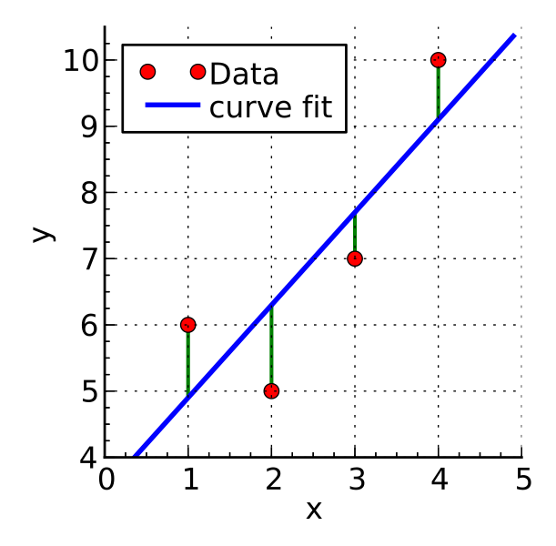

Obiges Beispiel zeigt eine mögliche Situation, bei der wir vier Daten Punkte haben, die nicht auf einer Linie liegen. Unser Ziel ist es, eine Linie zu finden, die bestmöglich zu all diesen Datenpunkten passt. Anders ausgedrückt, soll diese Linie möglichst nahe an allen Datenpunkten vorbeigehen. D.h., dass die Abstände der Datenpunkte zur Linie möglichst gering sein sollen. Bei einem gegebenen X Wert soll also der vorher gesagte Y Wert aus unserem linearen Modell möglichst nahe an dem Y Wert des Datenpunktes liegen, und dies soll für alle Punkte gleichzeitig der Fall sein. Dabei interessiert uns nicht, ob die Abweichung positiv oder negativ ist, also, ob die Linie über oder unter dem Punkt verläuft. Was wir minimieren wollen, ist der absolute Abstand. Mit einer Formel könnte man das wie folgt ausdrücken:

$min\sum_{i=1}^n (y_i - \hat{y})^2$

Wie schon in vielen anderen Situationen, so wird auch hier das Ignorieren des Vorzeichens des Abstandes dadurch erreicht, dass man den Wert quadriert. Und wir suchen genau die Linie, bei der die Summe der quadrierten Abstände der echten Y Werte von unseren vorher gesagten möglichst gering ist.

Grundsätzlich können wir vieles des Werkzeugs übernehmen, dass wir bereits für den einfachen zwei Daten Punkte Fall verwandt haben. Wir müssen zuerst die Steigung ausrechnen, und mit dieser Steigung können wir dann den Intercept bestimmen. Für die Steigung müssen wir bestimmen, wie insgesamt die Y Werte sich in Bezug auf die X Werte verändern, also den Durchschnitt der Veränderung der Y Werte bestimmen, die sich durch die X-Werte erklären lassen. D.h., wir müssen zuerst die Summe der mit den X-Werten und deren Änderung einhergehenden Veränderungen der Y Werte bestimmen. Diese Summe müssen wir dann durch die Summe der Veränderung der X Werte selbst teilen, um die durchschnittliche Veränderung des Y-Wertes pro Veränderung des X-Wertes feststellen zu können.

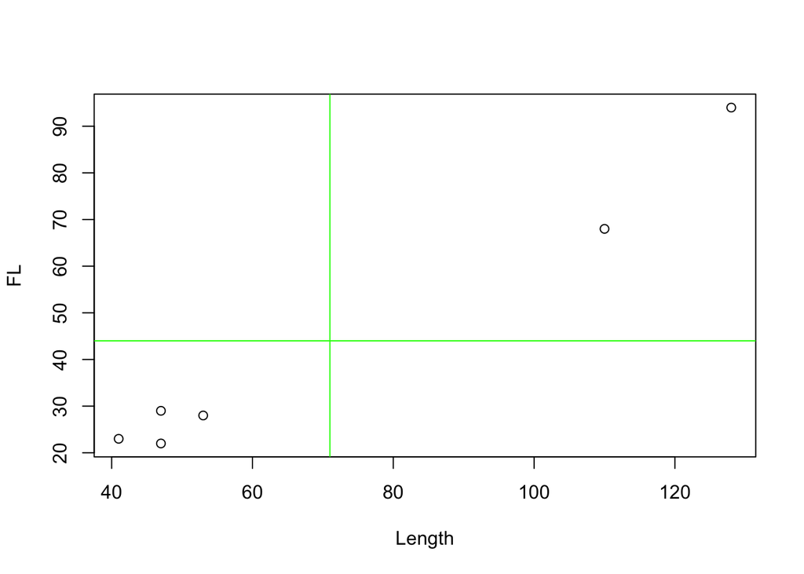

Doch wie können wir jetzt feststellen, wie sehr sich die Y Werte insgesamt in Bezug auf die Änderung der X Werte verändern? Tatsächlich ist es nicht einfach, diese Berechnung intuitiv herzuleiten. Man kann sie mathematisch durch Ableitung herausarbeiten, doch das ist ein Ansatz, den wir diesen Kurs nicht verfolgen wollen. Stattdessen kann ich Ihnen im folgenden nur Eine halb befriedigende Lösung geben. Durch die Intuition wird hoffentlich trotzdem klar, wie es funktioniert.

Als erstes einmal brauchen wir ein Mass, dass positiv und negativ sein kann, da wir positive und negative Regression haben. Eine negative Regression soll dann entstehen, wenn die Werte vor allen Dingen links oben und rechts unten in unserem Koordinatensystem verteilt sind, jeweils bezogen auf deren Mittelwert. Positiv soll der Wert werden, wenn die Punkte vor allen Dingen links unten und rechts oben im Koordinatensystem sich aufhalten.

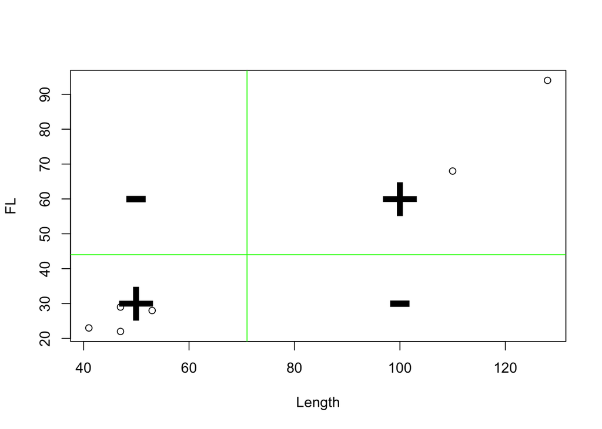

Zur Demonstration des Effektes müssen wir jetzt allerdings kurzfristig auf ein zufallsgeneriertes Datenset zurückgreifen. Unser reales Datensatz ist zu eindeutig positiv. Daher hier noch einmal eine vergleichbare Darstellung des zufällig generierten Datensatzes:

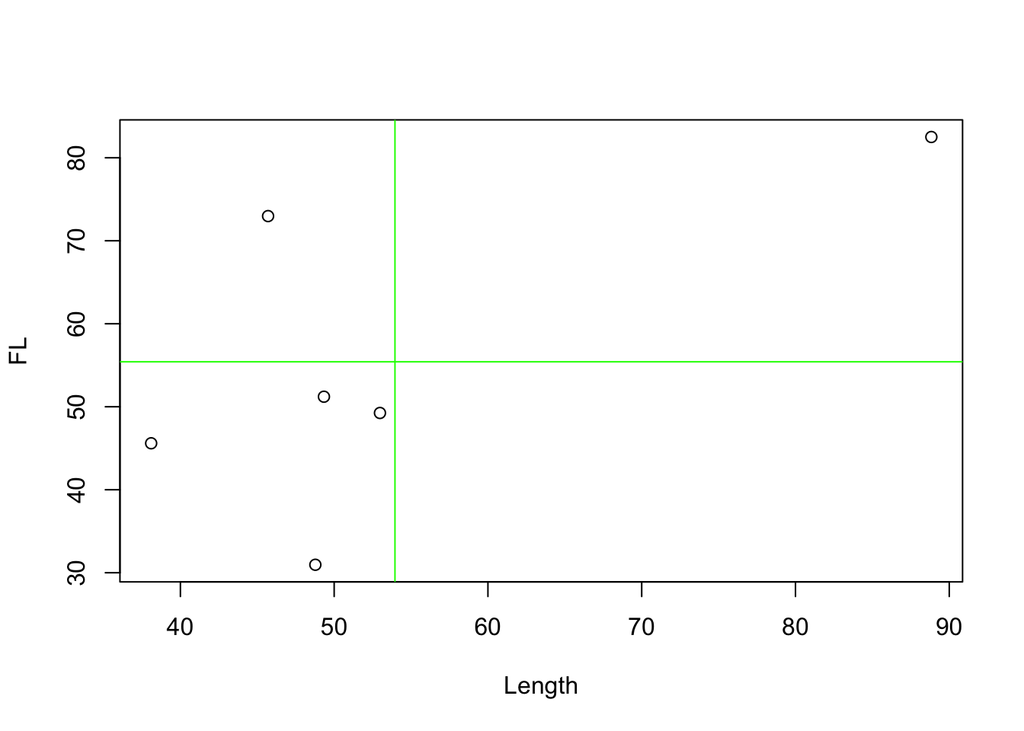

Jetzt betrachten wir für jeden die Abweichungen vom Mittelwert der entsprechenden Variable. Dieses Mal jedoch, ohne zu Quadrieren. D.h., wir behalten das Vorzeichen bei. Wenn unser Punkt auf der 1. Variable kleiner ist als der Mittelwert, dann wird sich hier ein negativer Wert einstellen. Das gleiche geschieht natürlich auch für die 2. Variable. Wenn der Wert umgekehrt grösser ist als der Mittelwert, dann wird es einen positiven Wert geben.

$(x_i - \bar{x})*(y_i - \bar{y})$

Und wir multiplizieren die entsprechenden Abweichungen. Nun kommt es darauf an, wie sich die Werte bezüglich beider variablen an einem Punkt verhalten. Sind beide kleiner als der jeweilige Mittelwert, So haben wir zwei negative Werte. Ihre Multiplikation wird daher einen positiven Wert geben. Sind beide grösser als der Mittelwert, werden beide Werte positiv sein, und auch ihr Produkt wird einen positiven Wert haben. Wenn jedoch einer der Werte kleiner als der Mittelwert ist, der andere aber grösser, dann wird das Produkt ein negativen Wert haben. Wir können uns für die Punkte dann auch entsprechend einmal die Werte anschauen:

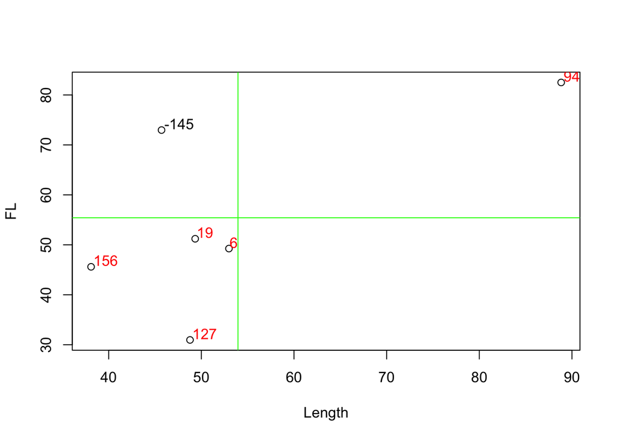

Positive Werte sind hier in rot eingefärbt, negative Werte in schwarz. Das Produkt der beiden Koordinaten kann man auch als Flächen Inhalt verstehen und entsprechend darstellen. Im folgenden Diagramm sind negative Flächen Inhalte in grau gehalten, positive sind rötlich eingefärbt.

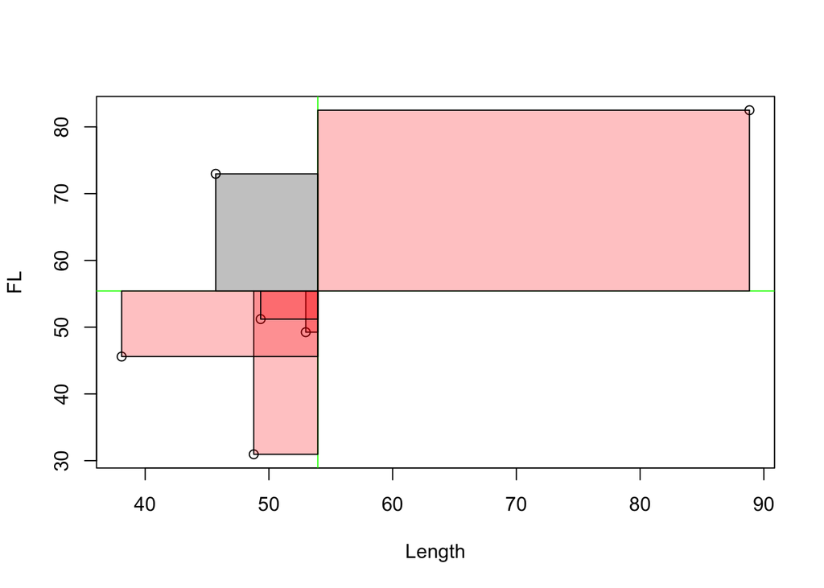

Wenn wir diese Flächen jetzt auf summieren, dann bekommen wir einen Wert für die Gesamtabweichung Der einzelnen Werte vom Mittelwert. Und zwar in Bezug auf beide variablen. Diesen wird nennt man **Kovarianz**. Er gibt an, wie beide variablen miteinander variieren. Häufig wird die Kovarianz auf die Anzahl-1 normiert, um ein durchschnittliches Kovarianzmass zu bekommen. Das tuen wir hier nicht! Viel mehr normierenden wir auf die Varianz von X.

Um dies zu erläutern und dazu stellen, nutzen wir eine etwas andere Darstellung: Die einzelnen Boxen können wir rausnehmen, und nebeneinander stellen. Und wir können Ihnen jeweils Quadrate gegenüberstellen, die einzig aus der Abweichung bezüglich der ersten variable bestehen.

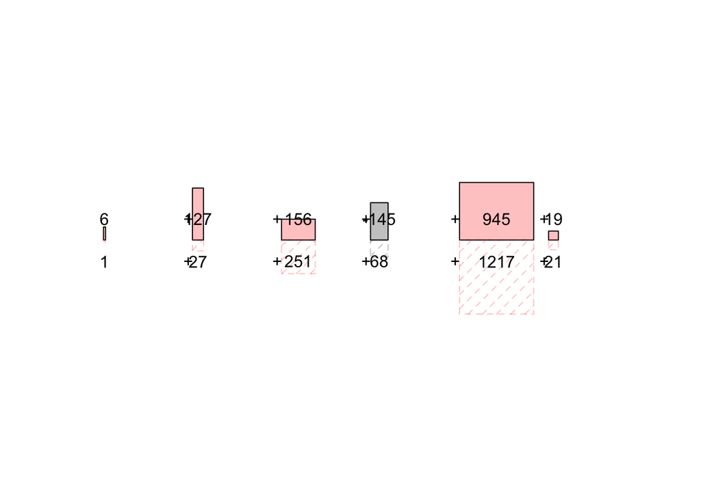

Was wir sehen können, ist folgendes: wenn die Box im oberen Bereich, also die gemeinsam Variabilität, grösser ist als die das Quadrat der Abweichungen von x alleine und damit der unteren Box, dann hat Y eine stärkere Abweichung als x. Eine regressionsgerade müsste stärker als 45° geneigt sein, was sich aus einem Verhältnis von 1/1 ergeben würde. Es ist die Box im oberen Bereich hingegen kleiner, da hat Y eine kleinere Abweichung, und die Regressionsgerade müsste flacher als 45° sein. Die Summe der Boxen wiederum gibt uns wieder, ob wir eine positive oder negative Regression insgesamt bei allen Datenpunkten ableiten müssen.

Insgesamt ergibt sich daraus folgende Formel:

$min\sum_{i=1}^n (y_i - \hat{y})^2 = b_{min} = \frac{\sum_{i=1}^n(x_i - \bar{x})*(y_i - \bar{y})}{\sum_{i=1}^n(x_i - \bar{x})^2}$

Im oberen Bereich sehen wir die **Kovarianz**: $\sum_{i=1}^n(x_i - \bar{x})*(y_i - \bar{y})$. This value increases when x and y vary in the same direction.

Im Nenner der Gleichung sehen wir die **Varianz von X**: $\sum_{i=1}^n(x_i - \bar{x})^2$. Wir dividieren jeweils die Summen der einzelnen Abweichungen vom Mittelwert, und nominieren so die gemeinsame Varianz von X und Y mit der Varianz von X. Je nachdem, in welchem Verhältnis die Variabilität von X zu Variabilität von Y steht, erhalten wir eine andere Steigung für unsere lineare Gleichung. Das Ganze ergibt die Antwort auf die Frage, wie sehr Y im Verhältnis zu X im Durchschnitt variiert.

Damit haben wir zwei jetzt unsere Steigung berechnet, als zweites benötigen wir jedoch noch den Intercept. Dazu benötigen wir einen Punkt, von dem aus wir die Steigung abtragen, gemäss unserer eingangs am einfachen zwei Punkte Fall durch gespielten Rechenweg. Und hierzu können wir jetzt nicht willkürlich irgendeinen der Punkte nehmen. Hierzu brauchen wir noch eine weitere Eigenschaft der gesuchten Trendlinie: eine Linie, Die die durchschnittlichen Abstände der Daten Punkte minimiert, muss zwangsläufig durch den Punkt gehen, der durch den Mittelwert der X und Y Werte bestimmt wird. Oder anders ausgedrückt hat, die Linie, die im Mittelwert alle Punkte am besten beschreibt, muss eben genau diesen Mittelwert auch beinhalten. D.h., Dass wir schon mal davon ausgehen können, dass unsere gerade durch einen Punkt mit den Koordinaten der Mittelwerte beider variablen gehen muss.

Das liegt auch daran, dass der Mittelwert so definiert ist, dass dieser der Punkt ist, der in der Summe der Abstände am wenigsten weit von allen Punkten entfernt liegt. Wenn wir also eine gerade erhalten wollen, die eben auch genau diese Abstände minimiert, ist der Mittelwert zwangsläufig beinhaltet.

$a_{min} = \bar{y} - b_{min} * \bar{x}$

Somit können wir also jetzt auch neben der Steigung den Durchstosspunkt an der Y Achse berechnen. Der zweite Teil war viel einfacher als der erste nicht wahr? Aber die Mühen haben sich gelohnt! Nun können Sie für jede. Wolke eine gerade berechnen, die diese bestmöglich beschreibt. Sie können ein lineares Modell aufstellen. Und das können Sie mit Zettel, Stift, und Taschenrechner. Vielleicht ist es nun fair, Ihnen zu sagen, dass R das natürlich Viel einfacher und schneller erledigen kann. Bevor ich ihn aber zeige, wie, spielen wir das ganze noch einmal an einem praktischen Beispiel durch, nämlich an unserem Münsingen Datensatz.

## Practical example

Als erstes laden wir den Münsingen Datensatz in unsere Arbeitsumgebung. Wie üblich, speichern Sie bitte dazu den Datensatz in ihrer Arbeitsverzeichnis, und laden ihn dann ein.

muensingen_fib.csv

```r
muensingen <- read.csv2("muensingen_fib.csv")
```

Jetzt betrachten wir unsere beiden variablen Fusslänge und Gesamtlänge. Der Übersichtlichkeit halber beschränken wir uns auf die ersten sechs Datenpunkte. Wir können auch gleich schon mal die Mittelwerte der beiden variablen bestimmen.

```r
head(muensingen[,c("FL","Length")])
```

```
##   FL Length
## 1 28     53
## 2 29     47
## 3 22     47
## 4 23     41
## 5 94    128
## 6 68    110
```

```r
colMeans(head(muensingen[,c("FL","Length")]))
```

```
##     FL Length
##     44     71
```

Als Nächstes bestimmen wir die Steigung unserer Regressionsgerade. Dazu wenn wir die Formel an, die wir uns eben arbeitet haben.

$b_{min} = \frac{\sum_{i=1}^n(x_i - \bar{x})*(y_i - \bar{y})}{\sum_{i=1}^n(x_i - \bar{x})^2}$

Wir brauchen also die Covarianz, und die Varianz von X, bzw. die Summe dieser Werte. Beides gebe ich unten in der Tabelle Schritt für Schritt für die einzelnen Merkmalsträger (Fibeln) an.

| FL | Length | FL - mean(FL) | Length - mean(Length) | covariance | var(L) |
| --- | --- | --- | --- | --- | --- |
| 28 | 53 | -16 | -18 | 288 | 324 |
| 29 | 47 | -15 | -24 | 360 | 576 |
| 22 | 47 | -22 | -24 | 528 | 576 |
| 23 | 41 | -21 | -30 | 630 | 900 |
| 94 | 128 | 50 | 57 | 2850 | 3249 |
| 68 | 110 | 24 | 39 | 936 | 1521 |
| sum |  |  |  | 5592 | 7146 |

$b_{min} = \frac{5592}{7146}$

Nach all den komplizierten Verfahren sollte und diese Division nun nicht überfordern:

$b_{min} = 0.7825357$

Somit haben wir die Steigung der Regressionsgerade berechnet. Diese setzen wir jetzt in die geraden Gleichung ein, und nutzen unseren Bezugspunkt, den Punkt, an dem sich beide Mittelwerte schneiden, also das Zentrum unserer Punktwolke. Die Mittelwerte hatten wir ja bereits oben schon ausgerechnet.

$a_{min} = \bar{y} - b_{min} * \bar{x}$

$a_{min} = 44 - 0.7825357 * 71$

Somit ergibt sich als intercept der folgende Wert:

$a_{min} = -11.5600336$

Eine theoretische Fibel der Länge null hätte eine Fusslänge von -11.6 mm. Für jede weitere Erhöhung der Länge der Fibel um 1 mm müssen wir ca 0.78 mm dazu rechnen.

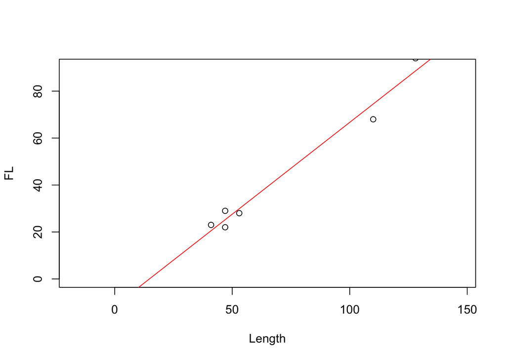

Natürlich müssen wir das in R nicht Schritt für Schritt machen, sondern wir können die Spalten unseres Datensatzes jeweils in die Formel einsetzen, so dass hier die gesamten Wert auf einmal durchgerechnet werden:

```r
mm <- data.frame(head(muensingen))
b.min <- sum(
  (mm$FL - mean(mm$FL)) * (mm$Length - mean(mm$Length))
  ) /
  sum((mm$Length - mean(mm$Length))^2)
b.min
```

```
## [1] 0.7825357
```

```r
a.min <- mean(mm$FL) - b.min * mean(mm$Length)
a.min
```

```
## [1] -11.56003
```

Und natürlich geht es auch noch kürzer. Diesen Befehl haben wir schon einmal eingesetzt, als wir eine entsprechende Trendlinie im Bereich der grafischen Darstellung und produziert haben. Der Befehl lautet `lm()`.

```r
lm(FL ~ Length, data=mm)
```

```
##
## Call:
## lm(formula = FL ~ Length, data = mm)
##
## Coefficients:
## (Intercept)       Length
##    -11.5600       0.7825
```

Was wir hier schreiben, bedeutet: Modelliere die Fusslänge in Abhängigkeit von der Länge im Datensatz mm. Das Ergebnis ist das Regressionsmodell, dass wir auch für weitergehende Untersuchungen verwenden können. Tatsächlich werden Sie feststellen, wenn sie sich noch weiter mit R und Modellierung beschäftigen, dass dieser Befehl auch in fortgeschritteneren Untersuchungen eine Rolle spielen wird. Sie haben hiermit einen Blick in das Reich der Modellierung geworfen. In diesem Bereich blühen viele wunderschöne Blumen, und es gibt viele spannende Dinge zu entdecken. Doch das verschieben wir auf ein andermal. Im weiteren werden wir uns jetzt mit dem Teambereich der Korrelation beschäftigen. Doch vorher können sie gerne ihre bisherigen Kenntnisse an einer praktischen Übung erproben.

Regression between number of millstones and number of cereal grains (Shennan example)

The number of cereal grains and millstones is given in different Neolithic settlements. Plot the relationship and specify the described regression equation.

File: cereal_processing.csv

**Solution**

Als erstes laden wir natürlich wieder einmal den Datensatz in die Arbeitsumgebung. Sie werden sicher schnell feststellen, dass es sich um einen “;”-getrennten Datensatz handelt, und dass die erste Spalte bereits die Zeilennummern enthält.

```r
cereal <- read.csv2("cereal_processing.csv", row.names = 1)
```

Als Nächstes sollen wir die Beziehung plotten, und ich werde gleich das lineare Modell als Regressionsgerade mit hinein zeichnen.

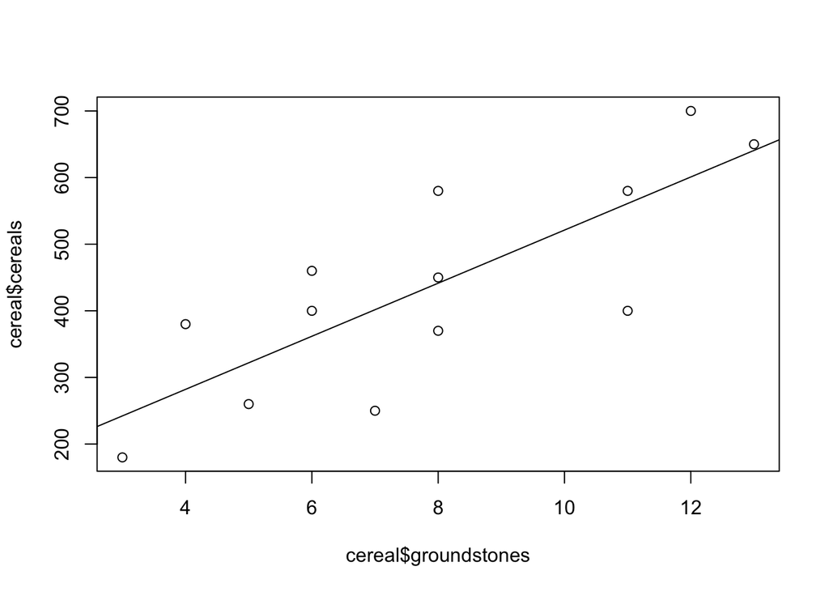

```r
plot(cereal$groundstones, cereal$cereals)
abline(lm(cereal$cereals ~ cereal$groundstones))
```

Wie Sie sehen können, sehe ich die Malsteine als unabhängige variable an, und die Anzahl von Getreideresten als abhängige Variable. Natürlich ist dies bereits Interpretation: man könnte sagen, dass dort, wo viele Mahlsteine vorhanden sind, auch viel Mehl gemahlen wird. Oder man könnte sagen, dass dort, wo viel Getreide vorhanden ist, auch ein grosser Bedarf an Mahlsteinen existiert. Die Frage, was die abhängige und was die unabhängige variable ist, hängt von der Forschungsfrage und der Vorinterpretation ab.

Gehen wir in jedem Fall noch einmal schnell die Werte für die Regressionsgerade an.

```r
lm(cereal$cereals ~ cereal$groundstones)
```

```
##
## Call:
## lm(formula = cereal$cereals ~ cereal$groundstones)
##
## Coefficients:
##         (Intercept)  cereal$groundstones
##              122.67                39.86
```

Diese Werte sagen, dass auch ohne mal Steine 123 Getreidereste vorhanden wären. Für jeden weiteren Mahlstein kommen circa 40 weitere Getreidereste dazu.

Bevor sie sich der Korrelation zu wenden, haben sie ja vielleicht noch Lust, den vollständigen Datensatz von Münsingen als lineares Modell zu modellieren? Bislang haben wir nur die ersten sechs Daten Punkte ausprobiert.

## Correlation

### Correlation coefficient in Theory

Das mit den gerade gewonnenen Erkenntnisse ist es uns nun möglich, das Verhältnis zweier variablen anhand von Daten ab zu schätzen. Wir können feststellen, ob es eine positive und eine negative Regression gibt. Und wir können sie sogar noch deutlich genauer bestimmen. Diese Regression stellt eine optimale Anpassung unseres Modells an die Daten da. Bislang können wir zwar nur lineare Regression an die Daten an passen, und das wird für diesen Kurs auch so bleiben. Aber gegeben diese Rahmenbedingungen, und somit die maximale Komplexität unseres Modells, ist dennoch die Regressionsgerade eine optimal angepasste Version dieses Modells an die Daten.

In der realen Welt werden die Datenpunkte immer von der Regressionsgerade abweichen. Sollten Sie es nicht tun, sollten sie sehr skeptisch werden! Aber abgesehen von einer visuellen Inspektion können wir im folgenden eine numerische Wiedergabe der Stärke und Bedingtheit des Zusammenhanges zwischen zwei variablen kennen lernen.

Zur Verdeutlichung noch einmal die Darstellung des gesamten Münsingen Datensatzes.

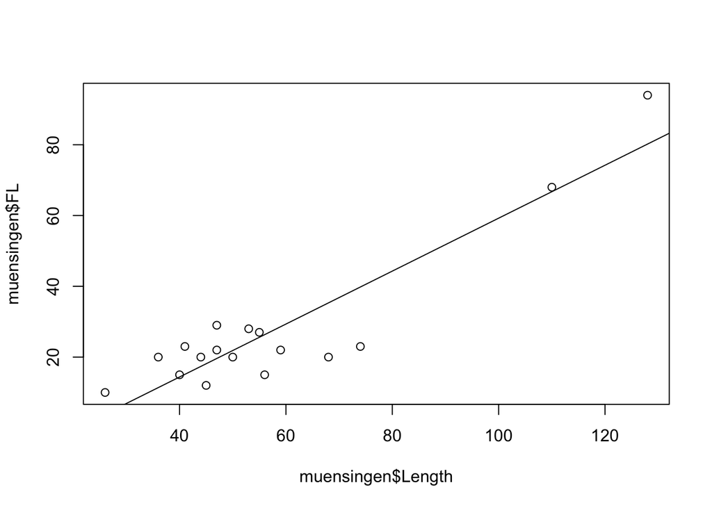

```r
plot(muensingen$Length, muensingen$FL)
abline(lm(muensingen$FL ~ muensingen$Length))
```

Was wir jetzt noch nicht wissen, ist, wie gut unser Modell auch unsere Daten tatsächlich beschreibt. Ein wichtiger Aspekt dabei ist, wie nahe die Datenpunkte tatsächlich sich bei unserer Regressionsgerade befinden. Um dies festzustellen, benutzt man den **Korrelationskoeffizient.** Dieser gibt an, wie stark oder besser wie zwingend der Zusammenhang zwischen zwei variablen ist. Wenn dieser Zusammenhang sehr stark ist, Dann wird auch ein Modell, dass sich in seiner Vorhersage nur auf die unabhängige variable stützt, ein gutes Ergebnis liefern. Ist der Zusammenhang jedoch schwach, und streuen die Punkte weit um eine gedachte Linie, dann ist das Modell, dass wir aus den Datenpunkten errechnen, auch nicht besonders vorhersagestark.

Ich schicke gleich mal die Formel zur Berechnung vorweg, sie lautet:

$r = \frac{\sum_{i=1}^n(x_i - \bar{x})*(y_i - \bar{y})}{\sqrt{\sum_{i=1}^n(x_i - \bar{x})^2* \sum_{i=1}^n(y_i - \bar{y})^2}}$

Sie werden feststellen, dass sich die Berechnung der Korrelation in vielen Bereichen der Schätzung der Regressionsgerade ähnelt. Der obere Teil der Rechenvorschrift ist exakt der gleiche, wie wir eben schon benutzt haben. Es handelt sich wiederum um die **Kovarianz**.

Der untere Teil, der die Kovarianz normiert, ist nun nicht die Varianz von X, sondern das Produkt der Varianzen der einzelnen variablen. Dieses steht unter einer Wurzel, da für X und für Y jeweils die Varianz berechnet wird, also die Werte quadriert werden. Und wenn diese beiden dann multipliziert werden, dann haben wir die quadrierte Varianz vorliegen. Um also Zähler und Nenner wieder auf das gleiche Mass zu bringen, müssen wir den unteren Term unter die Wurzel setzen.

Was dadurch geschieht, ist, dass die gemeinsame Varianz von X und Y ins Verhältnis gesetzt wird zur Gesamtvarianz in Bezug auf X und Y individuell. Dies lässt sich wie folgt interpretieren: wenn die Kovarianz, also der Anteil, bei dem X und Y in die gleiche Richtung variieren, Genauso gross ist wie die zusammengerechnet individuelle Varianz bei der variablen, dann ist alle Variabilität, die wir im Datensatz sehen, gemeinsame Variabilität. D.h., wann immer X grösser wird, wird Y um einen festen Betrag grösser oder kleiner. Oder anders gesagt: alle Punkte liegen auf einer Linie. Ob dies eine ansteigende (positive) oder abfallende (negative) Linie ist, geht aus der Kovarianz hervor. Diese kann ja positiv und negativ werden. Die einzelnen individuellen Varianten können nur positiv werden, demzufolge auch ihr Produkt beziehungsweise die Wurzel davon. D.h., dass der Nenner unsere Gleichung immer positiv sein wird. Demzufolge kann sich der Wert des Korrelationskoeffizienten zwischen -1 und 1 bewegen.

Liegen jedoch nicht alle Punkte auf einer Linie, dann wird die zusammen gerechnete individuelle Varianz der beiden variablen grösser sein als die Kovarianz. Damit wird der absolute Wert des Korrelationskoeffizienten kleiner. Ist dieser 0, dann besteht gar kein Zusammenhang, nicht mal ein rechnerischer, zwischen beiden variablen.

Also kann der Korrelationskoeffizient jeden Wert zwischen -1 und 1 annehmen. -1 wäre eine perfekte negative Korrelation, +1 eine perfekte positive Korrelation. Die Punkte würden auf einer Linie liegen. Jeder wird dazwischen deutet auf einen schwächeren Zusammenhang als eine perfekte Korrelation. Die Punkte streuen mehr oder weniger stark um eine gedachte Regressionslinie.

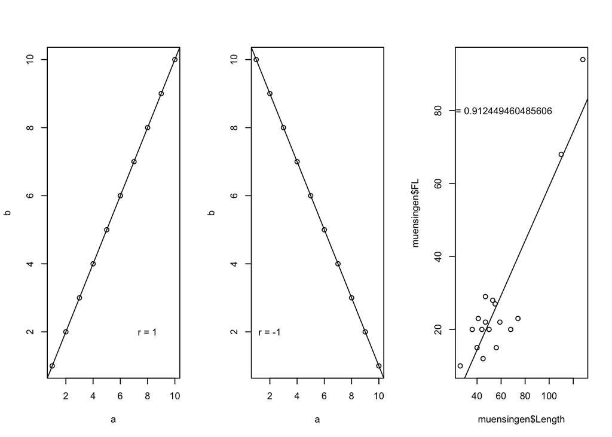

### Correlation coefficient in R

Auch wenn der Teil zur Korrelation nicht so lang ausgefallen ist wieder Teil zu Regression, so wird dennoch der Teil zur Umsetzung in R wiederum sehr viel kürzer sein. Wiederum können wir auf zwei Arten und Weisen das ganze in R nachvollziehen: Entweder, wir bauen die Formel nach, oder, wir nutzen die eingebaute Funktion. Wie immer, werden wir zuerst das eine, und dann das andere tun.

Hier noch einmal die Formel:

$r = \frac{\sum_{i=1}^n(x_i - \bar{x})*(y_i - \bar{y})}{\sqrt{\sum_{i=1}^n(x_i - \bar{x})^2* \sum_{i=1}^n(y_i - \bar{y})^2}}$

- upper part of the formula: $\sum_{i=1}^n(x_i - \bar{x})*(y_i - \bar{y})$ covariance
- lower part of the formula: $\sqrt{\sum_{i=1}^n(x_i - \bar{x})^2* \sum_{i=1}^n(y_i - \bar{y})^2}$ standardizes the covariance to both variances

Und hier die direkte Umsetzung in R:

```r
cov(muensingen$FL, muensingen$Length) /
  sqrt(var(muensingen$FL) * var(muensingen$Length))
```

```
## [1] 0.9124495
```

Wortwörtlich haben wir hier also die Covarianz von Fusslänge und Gesamtlänge, Und dies teilen wir durch die Wurzel der Multiplikation der Varianten der einzelnen Variablen.

Oder wir nutzen direkt den Befehl `cor()`.

```r
cor(muensingen$FL, muensingen$Length)
```

```
## [1] 0.9124495
```

### Coefficient of determination R²

Der Korrelationskoeffizient selbst ist bereits ein sehr praktisches Werkzeug. Ergibt uns einen Hinweis auf die stärke und die Richtung einer Korrelation. Allerdings ist ja schwer zu interpretieren. Erst Einheitenlos, und eine Verdopplung des Korrelationskoeffizienten heisst nicht, dass die Korrelation doppelt so stark geworden wäre. Das liegt an der Art, wie er berechnet wird.

Ein einfacher zu interpretieren Kennwert wäre einer, der die Gesamtvariabilität der Daten in das Verhältnis zu der Variabilität setzen würde, die das Modell erklären kann. Ein solcher Kennwert ist der Determinationskoeffizient, oder auch R². Die Formel für diesen Kennwort lautet:

$R^2 = \frac{Variance\ of\ the\ predicted\ values}{Variance\ of\ the\ measured\ values} = \frac{Explained\ sum\ of\ squares}{Total\ sum\ of\ squares} = \frac{\displaystyle\sum\nolimits \left(\hat{y}_i- \overline{y}\right)^2}{\displaystyle\sum\nolimits \left(y_i - \overline{y}\right)^2}$

Ich habe Ihnen drei Varianten gegeben. Der erste Teil zeigt, dass ihr die Varianz der Werte aus unserem linearen Modell durch die Varianz der realen Werte teilen. Was intuitiv dahinter steckt, Ist, dass das Modell einen gewissen Teil der Varianz erklären kann (die erklärte Summe der Quadrate), und dieses ins Verhältnis zur gesamten Varianz (gesamte Summe der Quadrate) gesetzt wird. D.h., dass dieser Wert angibt, Wie viel des rauf und runter dass der abhängigen variablen durch die Modellierung mittels der unabhängigen variablen erklärt werden kann. Oder noch kürzer, wie viel Der Struktur der Daten durch die Struktur des Modells wiedergegeben wird. Daher wird dieses Mass auch Bestimmtheitsmass genannt.

Das Schönste an dieser Formel, abgesehen von der Tatsache, dass man die intuitiv recht gut verstehen kann, ist, dass man sie in der Praxis auch gleich wieder vergessen kann. Den R² heisst nicht umsonst so. Wie Sie vielleicht gesehen haben, ist das Zeichen für den Korrelationskoeffizienten R. Und dank einer nicht zufälligen, aber sehr praktischen Eigenheit in der Berechnung ist ja auch nichts anderes als die Wurzel von R², Oder umgekehrt, der Determinationskoeffizient ist nichts anderes als das Quadrat des Korrelationskoeffizient.

Und da er das Verhältnis von erklärte Varianz zur Gesamtvariante darstellt, kann er auch sehr leicht interpretiert werden. Tatsächlich kann man den Wert als Prozent Erklärter Variabilität verwenden. Zum Beispiel, wie viel Prozent der Variabilität der Fusslänge lässt sich mit Kenntnis der Gesamtlänge erklären. Oder anders, zu wie viel Prozent hängt die Fusslänge von der Gesamtlänge der Fibel ab. Zu beachten ist, dass bei der Quadrierung natürlich auch wieder das Vorzeichen verloren geht. Das kann man als Nachteil sehen, das kann man aber auch als Vorteil betrachten: in diesem Zusammenhang ist es egal ob wir einen positiven oder negativen Zusammenhang haben. Der Koeffizient wird in beiden fällen über die stärke Auskunft erteilen.

In unserem Beispiel: r = 0.9124495, daher ist R² = 0.832564

Interpretieren können wir das wie folgt: 83.2564018% of the variation in foot length is explained by the length of the fibula! Aber Achtung: “explained” does not necessarily mean causal connection! Fragen von Kausalität können eigentlich immer nur ausserhalb der Statistik beantwortet werden. Die meisten statistischen Verfahren ist es egal, was abhängig und was unabhängige variable ist, oder ob es eine versteckte variable im Hintergrund gibt, die beiden variablen und ihr Zusammenspiel beeinflusst. Wir werden zum Ende des Kapitels noch mal kurz darauf eingehen.

## Correlation test

Nachdem wir jetzt nicht nur ein Modell aufstellen können, sondern seine Güte überprüfen können, wollen wir vielleicht auch noch wissen, ob unsere Aussage bezüglich der Korrelation und damit Güte des Modells signifikant ist. Hier ist es vor allen Dingen die Stichprobengrösse, die einen Einfluss darauf hat, wie sicher wir uns sein können, dass zwei variablen auch tatsächlich stark miteinander in Beziehung stehen. Wir haben ja immer nur eine Stichprobe, und wir wollen eigentlich eine Aussage über die Population treffen.

Auch hierfür gibt es, wieso häufig, eine parametrische und eine nicht parametrische Variante. Anders als sonst werden wir mit der parametrischen anfangen. Und wir werden sie auch dieses Mal nicht tiefgängig erklären. Das liegt unter anderem daran, dass die Grund Idee eigentlich sehr einfach ist. Es werden je nach Stichprobengrösse (Freiheitsgrade) Grenzwerte festgelegt, die für eine Normalverteilung gelten. Wenn unser Relations qualifizieren grösser ist als dieser Grenzwert in absoluten Zahlen, dann wird Dieser als Signifikant angesehen.

Dadurch, dass es sich vor allen Dingen auf normal verteilt werden bezieht, ist auch eine grundsätzliche Normalverteilung der Stichproben eine der Voraussetzungen, um einen Korrelationstest nach Pearson anzuwenden (Pearson ist übrigens auch der jenige, der Korrelationskoeffizienten, so wie wir ihn benutzt haben, “erfunden” hat).

Daher gleich in die Praxis: zuerst testen wir auf altbekannter Weise unsere Stichproben auf Normalverteilung (Shapiro oder KS, aber eher Shapiro…)

```r
shapiro.test(muensingen$FL)
```

```
##
##  Shapiro-Wilk normality test
##
## data:  muensingen$FL
## W = 0.63595, p-value = 2.37e-05
```

```r
shapiro.test(muensingen$Length)
```

```
##
##  Shapiro-Wilk normality test
##
## data:  muensingen$Length
## W = 0.80529, p-value = 0.0024
```

Wie schon so oft, so ist auch in diesem Fall der Shapiro Test skeptisch. Er glaubt nicht, dass unsere Daten normal verteilt sind. Wären Sie es, so könnten wir zum nächsten Schritt übergehen an, dem eigentlichen Test. Dieser ist sehr einfach mittels des Befehls `cor.test()` aufzurufen.

```r
cor.test(muensingen$FL,muensingen$Length)
```

```
##
##  Pearson's product-moment correlation
##
## data:  muensingen$FL and muensingen$Length
## t = 8.6363, df = 15, p-value = 3.314e-07
## alternative hypothesis: true correlation is not equal to 0
## 95 percent confidence interval:
##  0.7691077 0.9683922
## sample estimates:
##       cor
## 0.9124495
```

Im Ergebnis sehen wir als letzte Angabe den Korrelationskoeffizient, wie wir ihn ohnehin schon ausgerechnet hatten. Darüber ist ein Konfidenzintervall angegeben. Dies ist eine Schätzung der Unsicherheit, mit der sich die Korrelation berechnen lässt. Mit einer grösseren Stichprobe würde diese Unsicherheit kleiner werden, wir könnten die Korrelation der Populationen sicherer schätzen. Darüber sehen wir die den Wert der Teststatistik t, sowie die Freiheitsgrade. Entscheidend für uns aber ist der p-Wert. Dieser ist kleiner als 0.05, d.h., wären unsere Stichproben normal verteilt, könnten wir nun davon ausgehen, dass die Korrelation auch signifikant ist, also tatsächlich besteht (mit 95-prozentiger Wahrscheinlichkeit).

Sie können das gleich mal mit dem Datensatz zu den Mahlsteinen selbst in der Praxis erproben.

Correlation between number of millstones and number of cereal grains (Shennan example)

The number of cereal grains and millstones is given in different Neolithic settlements. Indicate how strongly the variables correlate with each other, how much of the variation of the millstones is explained by the cereal grains and whether the correlation is significant!

File: cereal_processing.csv

**Solution**

Falls sich der Datensatz nicht mehr in unserer R Umgebung befindet, Laden wir ihn erneut.

```r
cereal <- read.csv2("cereal_processing.csv", row.names = 1)
```

Als Nächstes sollen wir den Korrelationskoeffizienten und den Determinationskoeffizienten berechnen. Eigentlich die gleiche Rechnung, in der zweiten Durchführung Quadrieren wir aber einfach das Ergebnis.

```r
cor(cereal$groundstones, cereal$cereals)
```

```
## [1] 0.7908431
```

```r
cor(cereal$groundstones, cereal$cereals)^2
```

```
## [1] 0.6254327
```

Wie wir schon gesehen haben, gibt es eine positive Beziehung zwischen der Anzahl der Mahlsteine und der Anzahl der Getreideüberreste. Und der Korrelationskoeffizient beträgt demzufolge auch positive 0.79, Der Determinationskoeffizient ist mit 63% immer noch recht hoch. Tatsächlich ist ein R^2 von 30 % für viele Phänomene aus den Geisteswissenschaften schon eine ziemlich gute Korrelation.

Schliesslich sollen wir noch die Signifikanz prüfen. Also zweimal die Normalverteilung testen, und dann der Test auf Korrelation.

```r
shapiro.test(cereal$groundstones)
```

```
##
##  Shapiro-Wilk normality test
##
## data:  cereal$groundstones
## W = 0.95345, p-value = 0.6513
```

```r
shapiro.test(cereal$cereals)
```

```
##
##  Shapiro-Wilk normality test
##
## data:  cereal$cereals
## W = 0.96164, p-value = 0.7787
```

```r
cor.test(cereal$groundstones, cereal$cereals)
```

```
##
##  Pearson's product-moment correlation
##
## data:  cereal$groundstones and cereal$cereals
## t = 4.2857, df = 11, p-value = 0.001286
## alternative hypothesis: true correlation is not equal to 0
## 95 percent confidence interval:
##  0.4250859 0.9345882
## sample estimates:
##       cor
## 0.7908431
```

Na also! Shapiro kann keinen Signifikanz in Unterschiede feststellen, also behandeln wir die Datensätze normal verteilt. Die Korrelation ist laut dem Test statistisch signifikant. Allerdings lohnt es sich in jedem Fall, einen Blick auf die Vorhersagefehler zu werfen:

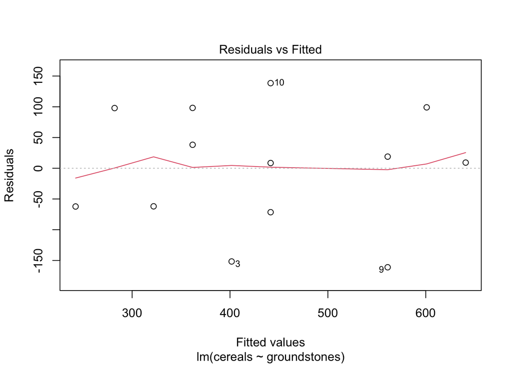

```r
plot(lm(cereals ~ groundstones, data=cereal), which=1)
```

Dieser Plot zeigt die Verteilung der Abweichungen der Werte von denen, die das Modell vorher gesagt hat, über den Bereich der Wert selbst. Ohne hier auf Details eingehen zu wollen, ist es gut, wenn die Werte dabei kein klares Muster zeigen, sondern ziemlich zufällig über den gesamten Wertebereich verteilt zum liegen kommen. Ist ein klares Muster vorhanden, so passt das Modell in bestimmten Wertbereichen besser als in anderen, und das kann die Einschätzung der Korrelation deutlich erschweren. Sie können das hier schon mal als pro Tipp abbuchen. Andererseits kann es durchaus kommen, dass ein Gutachter Ihnen mal eine ihrer Statistiken aufgrund der Residuen um die Ohren haut…

## Correlation of ordinally scaled variables

Wir gerade im Beispiel gesehen haben, ist häufig gerade in archäologischen Datensätzen nicht immer davon auszugehen, dass wir es mit Werten zu tun haben, die einem Korrelationstest genügen. Ausserdem haben wir häufig ja auch nicht metrische Daten, und auch hier ist es sicher interessant, festzustellen, ob eine Beziehung zwischen diesen Daten vor liegt. Für die Frage nach Beziehungen haben wir bereits den Chiquadrat Test kennen gelernt. Wenn wir aber ordinallskaliert variablen verwenden können, dann kann ein solcher Test auch mit Hörer Trennschärfe agieren.

Für beide Fälle gibt es die Möglichkeit, auf eine nicht parametrische Version der Korrelation und das Korrelationstestes auszuweichen. In diesem Fall spricht man von Rang Korrelation, d.h., wir beurteilen, ob mit dem steigen der einen Variable auch der andere Variable steigt (oder fällt), Und ob die sich als Muster durch den gesamten Datensatz in durchzieht. Hierfür gibt es zwei Versionen:

- Kendall’s $\tau$ (tau)
- Spearmans $\rho$ (rho)

Es gibt Argumente für beide Tests. In der Praxis sind ihre Ergebnisse aber meistens sehr ähnlich. Wir beschränken uns hier auf Kendall’s $\tau$, weil sich dieses sehr schön darstellen lässt. Als Beispiel nutzen wir einen Datensatz aus dem Stephen Shennan Buch: Die Grösse von Siedlungen in Abhängigkeit von der Qualität des Bodens. Diese Daten sind ordinalskaliert: Die Grösse ist in Klassen eingeteilt, die Qualität des Bodens in Gut, Mittel und Arm.

|  | poor | medium | good | Sum |
| --- | --- | --- | --- | --- |
| small | 15 | 7 | 2 | 24 |
| medium | 6 | 11 | 4 | 21 |
| big | 7 | 7 | 8 | 22 |
| Sum | 28 | 25 | 14 | 67 |

## Kendall’s $\tau$ (tau) Fact Sheet

Berechnung der Korrelation über die Übereinstimmung der Rangabfolgen

**Prerequisites**: Two at least ordinally scaled variables of a random sample

**Idea**: With a perfect correlation, all large settlements are located on the good soils, all medium ones on the medium and all small ones on the bad.

The calculation is based on possible pairings of values whose ranks are compared to each other. If both x and y values are smaller for a pairing than is the case at the comparison pair, the result is a concurrent pairing (with both have the same ranking). If the x value is greater for a pairing, but the y value is smaller, then it’s a discordant pair. Wie das zu verstehen ist, lässt sich am besten am praktischen Beispiel demonstrieren.

## Kendall’s $\tau$ (tau) in pratice

Als erstes bestimmen wir die Anzahl der übereinstimmenden Ränge. Die Ränge beider Variablen bei zwei Merkmalsträgern stimmen dann überein, Wenn sie beide jeweils höher sind als die des Vergleichsobjektes. Wir beginnen einmal bei den Siedlungen, die auf der schlechtesten Boden liegen, und die am kleinsten sind. Für diese zählen wir nun, mit wie vielen anderen wir sie vergleichen können, so dass sowohl der Boden als auch die Siedlungsgrösse einen niedrigeren rang hat. Das sind alle anderen Siedlungen, die mindestens einen besseren Boden und gleichzeitig eine grössere Siedlungsgrösse aufweisen. In diesem Fall stimmen beim Vergleich die Ränge der beiden variablen über ein.

|  | poor | medium | good | Sum |
| --- | --- | --- | --- | --- |
| small | 15 (a) | 7 (d) | 2 (g) | 24 |
| medium | 6 (b) | 11 (e) | 4 (h) | 21 |
| big | 7 (c) | 7 (f) | 8 (i) | 22 |
| Sum | 28 | 25 | 14 | 67 |

Jetzt zählen wir, wie viele mögliche Paarungen sich finden lassen, bei denen das der Fall ist. Dazu multiplizieren wir die Anzahl der kleinen Siedlungen Auf schlechten Boden mit der Anzahl der jenigen, die grösser sind und einen besseren Boden aufweisen. Praktisch heisst das: All settlements in cell (a) can be combined with all settlements in e,f,h,i so that both soil quality and settlement size are greater in a than in e,f,h,i.

Somit können wir die Werte in E, F, H, und I Addieren, und sie mit der Zahl der Siedlungen in A multiplizieren.

Pairings: a * (e+f+h+i)= 15 * (11+7+4+8)=450

Es lassen sich also 450 Paarungen finden, bei denen die Ränge bei der variablen über einstimmen. Das gleiche setzen wir nun für die nächste Zelle fort, z.B. die mittelgrossen Siedlungen auf schlechten Boden.

|  | poor | medium | good | Sum |
| --- | --- | --- | --- | --- |
| small | 15 (a) | 7 (d) | 2 (g) | 24 |
| medium | 6 (b) | 11 (e) | 4 (h) | 21 |
| big | 7 (c) | 7 (f) | 8 (i) | 22 |
| Sum | 28 | 25 | 14 | 67 |

Übereinstimmend höhere Ränge können nun nur noch die Siedlungen haben, die eine grosse Grösse aufweisen. Da unsere mittel grossen Siedlungen auf armen Böden sind, sind jetzt die grossen Siedlungen auf dem mittleren und guten Böden entscheidend. Deren Anzahl zählen wir zusammen und multiplizieren Sie wiederum mit der Anzahl der mittelgrossen Siedlungen auf schlechten Böden. Konkret: All settlements in cell b can be combined with all settlements in f,i, so that both soil quality and settlement size in a are greater than in f,i.

Pairings: b*(f+i)= 6*(7+8)=90

Das gleiche nur noch für die kleinen Siedlungen auf Mittel guten Böden:

|  | poor | medium | good | Sum |
| --- | --- | --- | --- | --- |
| small | 15 (a) | 7 (d) | 2 (g) | 24 |
| medium | 6 (b) | 11 (e) | 4 (h) | 21 |
| big | 7 (c) | 7 (f) | 8 (i) | 22 |
| Sum | 28 | 25 | 14 | 67 |

All settlements in cell d can be combined with all settlements in h,i, so that both soil quality and settlement size in a are greater than in h,i.

Pairings: d*(h+i)= 7*(4+8)=84

Und letztendlich für die mittelgrossen Siedlungen auf Mittelguten Böden.

|  | poor | medium | good | Sum |
| --- | --- | --- | --- | --- |
| small | 15 (a) | 7 (d) | 2 (g) | 24 |
| medium | 6 (b) | 11 (e) | 4 (h) | 21 |
| big | 7 (c) | 7 (f) | 8 (i) | 22 |
| Sum | 28 | 25 | 14 | 67 |

All settlements in cell e can be combined with all settlements in i, so that both soil quality and settlement size in a are greater than in i.

pairings: e*i= 11*8=88

Bei unseren variablen Ausprägungen lassen sich nun keine weiteren Beispiele für übereinstimmende Ränge finden. Es gibt ja keine grösseren Wert mehr als gross und gut, daher können hier im Vergleich auch keine Übereinstimmungen mehr gefunden werden, bei denen beide grösser sind. Daher sind wir nun mit den übereinstimmenden Rängen fertig, und können die Zahl zusammen zählen.

Pairs: C=450+90+84+88=712

Im Datensatz lassen sich also 712 Paarungen bilden, bei denen zwischen den einzelnen Siedlungen bei einem der beiden sowohl die eine als auch die andere Variable gleichzeitig grösser ist.

Nun vollziehen wir das gleiche Spiel mit den nicht übereinstimmenden Rängen. Hier zu starten wir in unserer Tabelle nun in der rechten oberen Ecke. Für kleine Siedlungen auf guten Böden lassen sich nun all die Siedlungen heranziehen, die gleichzeitig auf schlechteren Böden zu finden sind, aber grösser sind. Somit ist das Verfahren Spiegel symmetrisch für das, was wir für die übereinstimmenden Ränge angewandt haben.

|  | poor | medium | good | Sum |
| --- | --- | --- | --- | --- |
| small | 15 (a) | 7 (d) | 2 (g) | 24 |
| medium | 6 (b) | 11 (e) | 4 (h) | 21 |
| big | 7 (c) | 7 (f) | 8 (i) | 22 |
| Sum | 28 | 25 | 14 | 67 |

All settlements in cell g can be combined with all settlements in b,c,e,f, so that soil quality is worse, but settlement size is larger than in b,c,e,f.

Pairings: g*(b+c+e+f)=2*(6+11+7+7)=62

Weiter mit den mittelgrossen Siedlungen auf guten Böden:

|  | poor | medium | good | Sum |
| --- | --- | --- | --- | --- |
| small | 15 (a) | 7 (d) | 2 (g) | 24 |
| medium | 6 (b) | 11 (e) | 4 (h) | 21 |
| big | 7 (c) | 7 (f) | 8 (i) | 22 |
| Sum | 28 | 25 | 14 | 67 |

All settlements in cell h can be combined with all settlements in c,f, so that soil quality is worse, but settlement size larger than in c,f.

pairings: h*(c+f)=4*(7+7)=56

Nun mit den kleinen Siedlungen auf Mittelguten Böden:

|  | poor | medium | good | Sum |
| --- | --- | --- | --- | --- |
| small | 15 (a) | 7 (d) | 2 (g) | 24 |
| medium | 6 (b) | 11 (e) | 4 (h) | 21 |
| big | 7 (c) | 7 (f) | 8 (i) | 22 |
| Sum | 28 | 25 | 14 | 67 |

All settlements in cell d can be combined with all settlements in b,c, so that soil quality is worse, but settlement size larger than in b,c.

pairings: d*(b+c)=7*(6+7)=91

Und schliesslich mit den mittelgrossen Siedlungen auf Mittelguten Böden:

|  | poor | medium | good | Sum |
| --- | --- | --- | --- | --- |
| small | 15 (a) | 7 (d) | 2 (g) | 24 |
| medium | 6 (b) | 11 (e) | 4 (h) | 21 |
| big | 7 (c) | 7 (f) | 8 (i) | 22 |
| Sum | 28 | 25 | 14 | 67 |

All settlements in cell e can be combined with all settlements in c, so that soil quality is poorer, but settlement size is larger than in c.

pairings: e*c=11*7=77

Damit sind wir auch hier fertig, und können die Paarungen zusammen zählen. The number of pairings with discordant ranks is therefore the sum of the individual possible pairings.

Pairs: D=62+56+91+77=286

Jetzt haben wir alle Werte zusammen, um festzustellen, in welche Richtung und wie stark hier eine Korrelation vorliegt. Wir brauchen die Anzahl der Paarungen mit übereinstimmenden Ränge (C=712), die Anzahl der Paarungen mit nicht übereinstimmenden Rängen (D=286), dazu noch die Gesamtanzahl der Fälle im Datensatz (67) und die Mindestzahl der Zeilen oder Spalten (in diesem Fall sind beide gleich, d.h., wie können uns eine 3 auswählen), um die Freiheitsgrade bestimmen zu können, die auch hier eine Rolle spielen.

Die Formel zur Berechnung von $\tau$ sieht nun so aus:

$\tau_c = \frac{C-D}{\frac12 * n^2 * \frac{m-1}{m}}\ with\ m=min(n_{row}, n_{col})$

Setzen wir mal unsere Werte ein, und rechne das durch:

$n = 67; C=712; D = 286; m=3$

$\tau_c = \frac{712-286}{\frac12 * 67^2 * \frac{3-1}{3}}$

$\tau_c = \frac{426}{1496.3}$

$\tau_c = 0.285$

Dieser Tau-Wert zeigt eine schwache Korrelation an. In R ist eine etwas andere Variante implementiert: anstatt Kendalls $\tau$ C wird hier Kendalls $\tau$ B berechnet. Demzufolge ist der dort berechnete Tau-Wert auch etwas anders.

```r
soil <- read.csv2("soilsites.csv", row.names = 1)
cor.test(soil$size, soil$soil_quality, method = "kendall")
```

```
##
##  Kendall's rank correlation tau
##
## data:  soil$size and soil$soil_quality
## z = 2.6372, p-value = 0.008359
## alternative hypothesis: true tau is not equal to 0
## sample estimates:
##       tau
## 0.2902363
```

Wie Sie sehen, nutzt man hier gleich den `cor.test()` Befehl. Im Ergebnis ist die leichte Korrelation, die wir erschliessen können, auch statistisch signifikant. Vergleichen wir das Spearmans $\rho$:

```r
soil <- read.csv2("soilsites.csv", row.names = 1)
cor.test(soil$size, soil$soil_quality, method = "spearman")
```

```
##
##  Spearman's rank correlation rho
##
## data:  soil$size and soil$soil_quality
## S = 34237, p-value = 0.008993
## alternative hypothesis: true rho is not equal to 0
## sample estimates:
##       rho
## 0.3168415
```

Im Allgemeinen sind die Werte für Spearmans $\rho$ Meist etwas höher als die des Kendalls $\tau$. Dennoch ist auch dieser Wert signifikant. In der Praxis bietet sich oft an, einfach beide Werte mit anzugeben.

Somit können wir jetzt also auch für nicht normal verteilte, und sogar für originalskaliert variablen Korrelationen errechnen, und prüfen, ob diese statistisch signifikant sind.

## Correlation does not imply causation

Dies ist eine stehende Redewendung nicht nur innerhalb der Statistik selbst. Wenn wir eine Beziehung zwischen zwei variablen entdecken, dann heisst das nicht zwingend, dass eine auch die andere tatsächlich bedingt und direkt beeinflusst. Einerseits bleibt uns immer die Irrtumswahrscheinlichkeit, die wir ja in den allermeisten fällen mit 0.05 oder 5 % angeben. Zum anderen gibt es aber auch hier häufig unbeobachtete Einfluss Faktoren, wie zum Beispiel beide Varianten gleichzeitig bedingen. Zwar korrelieren diese beiden dann miteinander, der Grund dafür ist aber, dass beide durch eine dritte variable beeinflusst werden.

Ein Beispiel, dass du für häufig herangezogen wird, ist die Korrelation zwischen der Anzahl der Störche und der Anzahl der Geburten. Dass ihr eine Korrelation vor liegt, ist kein Nachweis dafür, dass der Storch tatsächlich irgendetwas mit den Geburten zu tun hat. Often it is hidden complex third variables that influence two correlating variables, e.g. the changes in modern society, which influence both the decline of storks and births.

Es gibt eine Internetseite, die sich zur Aufgabe gemacht hat, solche und ähnliche irreführende Korrelationen zusammen und darzustellen: http://www.tylervigen.com/spurious-correlations. Viel Spass beim studieren!

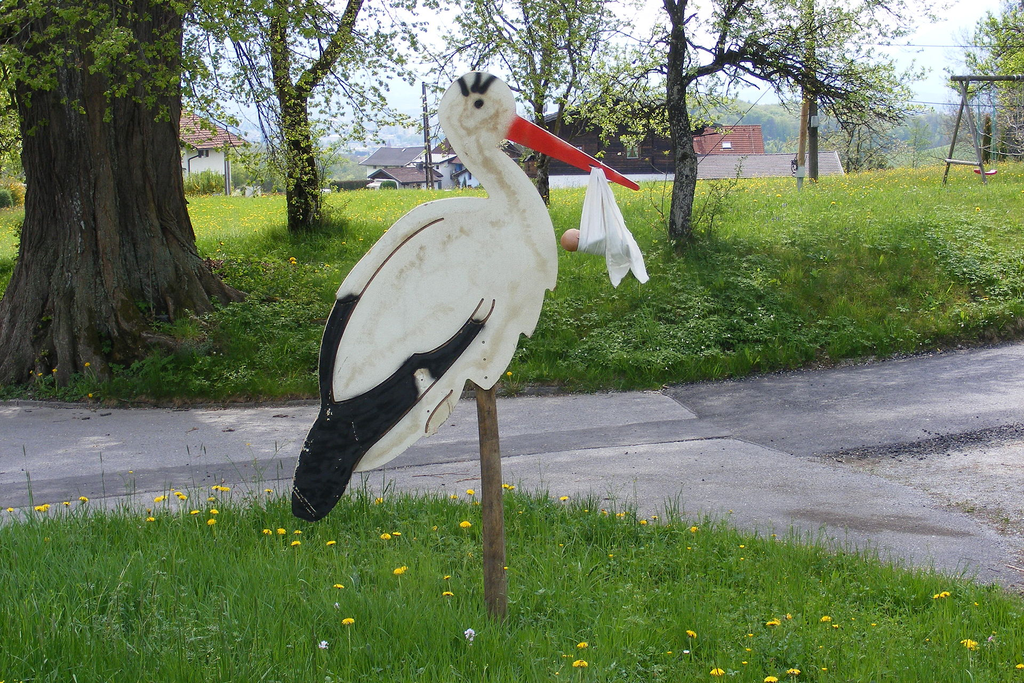